# Final Assignment, Task 2

Tue Minh Nguyen

20/10/2024

## Task 2 description

The COVID-19 pandemic has created a complex global dataset that includes infection rates, recovery statistics, testing figures, and death tolls. Analyzing this data is crucial for understanding the pandemic’s impact, but its volume and fragmentation present challenges for researchers and public health officials. Task 2 aims to extract meaningful insights by focusing on key metrics such as daily death tolls and cumulative case trends. Key objectives include identifying the peak death toll, visualizing cumulative data, analyzing statistics for the top 10 countries, and assessing confirmed cases by continent. The anticipated outcome of this task is a comprehensive analysis that provides insights into trends and statistics, supported by visualizations that illustrate changes in COVID-19 metrics over time, ultimately aiding informed public health decision-making.

```r
library(dplyr)
```

```r
library(ggplot2)
library(reshape2)
library(tidyverse)
library(tidyr)
covid19_data <- read.csv("~/data/covid19_data.csv")
```

# Task 2: Task 2: Exploratory Data Analysis:

1. Find the day with the highest death toll reported across the world. Print the date and the death toll of that day.

```r
# Ensure the date column is in Date format
covid19_data$Date <- as.Date(covid19_data$Date)

# Aggregate the total deaths by date
deaths <- covid19_data %>%
  group_by(Date) %>%
  summarise(total_deaths = sum(NewDeaths, na.rm = TRUE))

# Find the date with the highest death toll
death_day_max <- deaths %>%
  filter(total_deaths == max(total_deaths, na.rm = TRUE))

# Display the date with the highest death toll and the total deaths for that date
cat("The day with the highest death toll reported across the world is:",
    as.character(death_day_max$Date),
    "with a death toll of:",
    death_day_max$total_deaths, "\n")
```

```
## The day with the highest death toll reported across the world is: 2020-04-16 with a death toll of: 10520
```

2. Build a graph to show how the cumulative data of (Infected Cases, Deaths, Recovered, Tests) change over the time for the whole world collectively.

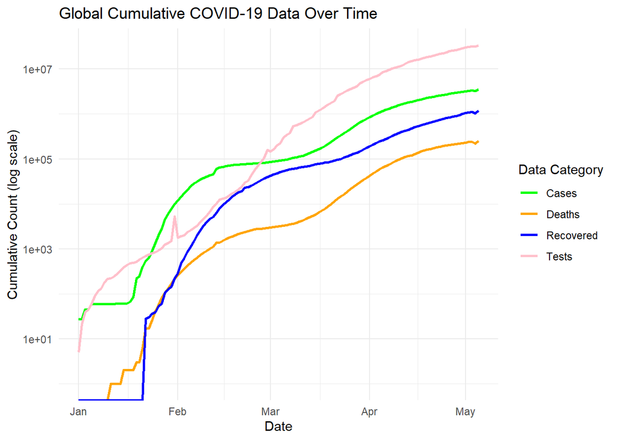

```r
# Convert the Date column in covid19_data to a Date object to ensure correct date formatting
covid19_data$Date <- as.Date(covid19_data$Date)

# Aggregate data by Date, summing up cumulative values for Cases, Deaths, Recoveries, and Tests across all records
global_totals <- covid19_data %>%
  group_by(Date) %>%   # Group the data by each unique date
  summarize(
    TotalCases = sum(CumCases, na.rm = TRUE),        # Calculate the total cases for each date
    TotalDeaths = sum(CumDeaths, na.rm = TRUE),      # Calculate the total deaths for each date
    TotalRecovered = sum(CumRecovered, na.rm = TRUE), # Calculate the total recoveries for each date
    TotalTests = sum(CumTests, na.rm = TRUE)         # Calculate the total tests for each date
  ) %>%
  ungroup()  # Ungroup the data to prevent unintended grouping in later operations

# Create a line plot showing cumulative cases, deaths, recoveries, and tests over time
ggplot(global_totals, aes(x = Date)) +   # Set the x-axis as Date to plot over time
  geom_line(aes(y = TotalCases, color = "Cases"), linewidth = 1) +     # Add a line for cumulative cases
  geom_line(aes(y = TotalDeaths, color = "Deaths"), linewidth = 1) +   # Add a line for cumulative deaths
  geom_line(aes(y = TotalRecovered, color = "Recovered"), linewidth = 1) +  # Add a line for cumulative recoveries
  geom_line(aes(y = TotalTests, color = "Tests"), linewidth = 1) +     # Add a line for cumulative tests

  # Apply a logarithmic scale to the y-axis for better visualization of differences in large values
  scale_y_log10() +

  # Set labels for the axes and add a descriptive title
  labs(
    x = "Date",  # Label for the x-axis
    y = "Cumulative Count (log scale)",  # Label for the y-axis
    title = "Global Cumulative COVID-19 Data Over Time",  # Chart title
    color = "Data Category"  # Title for the color legend
  ) +

  # Customize colors for each data category line
  scale_color_manual(values = c("Cases" = "green", "Deaths" = "orange", "Recovered" = "blue", "Tests" = "pink")) +

  # Apply a minimal theme for a clean chart appearance
  theme_minimal()
```

3. Extract the data corresonding to the last day *(05/05/2020)* for all countries and save it in a separate dataframe and name it *“lastDay_data”*.

   [Hint: use filter function with Date = “2020-05-05”]

```r
# Ensure the 'Date' column is in Date format
covid19_data$Date <- as.Date(covid19_data$Date)

# Extract data for the last day (05/05/2020)
lastDay_data <- covid19_data %>%
  filter(Date == as.Date("2020-05-05"))

# Display the extracted data for the last day
lastDay_data
```

```
##     Code                          Country     Continent       Date NewCases
## 1    AFG                      Afghanistan          Asia 2020-05-05      190
## 2    ALB                          Albania        Europe 2020-05-05        8
## 3    DZA                          Algeria        Africa 2020-05-05      174
## 4    AND                          Andorra        Europe 2020-05-05        2
## 5    AGO                           Angola        Africa 2020-05-05        0
## 6    AIA                         Anguilla North America 2020-05-05        0
## 7    ATG              Antigua and Barbuda North America 2020-05-05        0
## 8    ARG                        Argentina South America 2020-05-05      104
## 9    ARM                          Armenia        Europe 2020-05-05      121
## 10   ABW                            Aruba North America 2020-05-05        0
## 11   AUS                        Australia       Oceania 2020-05-05       24
## 12   AUT                          Austria        Europe 2020-05-05       24
## 13   AZE                       Azerbaijan        Europe 2020-05-05       52
## 14   BHS                          Bahamas North America 2020-05-05        0
```

[output cut: 817 more lines]

4. Based on the data in *“lastDay_data”* dataframe, extract the corresponding records of the top 10 countries worldwide with current active cases, total confirmed cases, or fatality rate in separate dataframes (*i.e.*, top10activeW, top10casesW, top10fatalityW, top10testsMW).

   [Hint: you can use head(arranged_data, n=10) to get the top 10 records and pass the records of these 10 countries in newly created data frames]

```r
# Extract the top 10 countries with the highest current active cases
top10activeW <- lastDay_data %>%
  arrange(desc(Active)) %>%  # Arrange by active cases in descending order
  head(n = 10)               # Select the top 10 countries

# Extract the top 10 countries with the highest total confirmed cases
top10casesW <- lastDay_data %>%
  arrange(desc(CumCases)) %>%  # Arrange by cumulative cases in descending order
  head(n = 10)                 # Select the top 10 countries

# Extract the top 10 countries based on fatality rate
top10fatalityW <- lastDay_data %>%
  arrange(desc(FatalityRate)) %>%  # Arrange by fatality rate in descending order
  head(n = 10)                     # Select the top 10 countries

# Extract the top 10 countries based on total tests conducted
top10testsMW <- lastDay_data %>%
  arrange(desc(CumTests)) %>%  # Arrange by cumulative tests in descending order
  head(n = 10)                 # Select the top 10 countries

# Display the top 10 dataframes for active cases, total cases, fatality rate, and total tests
top10activeW
```

```
##    Code                  Country     Continent       Date NewCases NewDeaths
## 1   USA United States of America North America 2020-05-05    22593      1252
## 2   GBR           United Kingdom        Europe 2020-05-05     3985       288
## 3   RUS                   Russia        Europe 2020-05-05    10581        76
## 4   ITA                    Italy        Europe 2020-05-05     1221       195
## 5   ESP                    Spain        Europe 2020-05-05      545       164
## 6   FRA                   France        Europe 2020-05-05      576       306
## 7   BRA                   Brazil South America 2020-05-05     6633       296
## 8   TUR                   Turkey          Asia 2020-05-05     1614        64
## 9   NLD              Netherlands        Europe 2020-05-05      199        26
## 10  IND                    India          Asia 2020-05-05     3900       195
##    Recovered NewTests Population      GDP GDPCapita Month Week CumCases
## 1       2611        0  327167434 19485394     60055     5   18  1180634
## 2         16    69839   66488991  2631228     39758     5   18   190584
## 3       1770   157114  144478050  1530750     10956     5   18   145268
```

[output cut: 29 more lines]

```r
top10casesW
```

```
##    Code                  Country     Continent       Date NewCases NewDeaths
## 1   USA United States of America North America 2020-05-05    22593      1252
## 2   ESP                    Spain        Europe 2020-05-05      545       164
## 3   ITA                    Italy        Europe 2020-05-05     1221       195
## 4   GBR           United Kingdom        Europe 2020-05-05     3985       288
## 5   DEU                  Germany        Europe 2020-05-05      685       139
## 6   RUS                   Russia        Europe 2020-05-05    10581        76
## 7   FRA                   France        Europe 2020-05-05      576       306
## 8   TUR                   Turkey          Asia 2020-05-05     1614        64
## 9   BRA                   Brazil South America 2020-05-05     6633       296
## 10  IRN                     Iran          Asia 2020-05-05     1223        74
##    Recovered NewTests Population      GDP GDPCapita Month Week CumCases
## 1       2611        0  327167434 19485394     60055     5   18  1180634
## 2       2143        0   46723749  1314314     28354     5   18   218011
## 3       2352    55263   60431283  1943835     32747     5   18   211938
```

[output cut: 29 more lines]

```r
top10fatalityW
```

```
##    Code                  Country     Continent       Date NewCases NewDeaths
## 1   NIC                Nicaragua North America 2020-05-05        1         0
## 2   COM                  Comoros        Africa 2020-05-05        1         1
## 3   FRA                   France        Europe 2020-05-05      576       306
## 4   SXM             Sint Maarten North America 2020-05-05        0         0
## 5   YEM                    Yemen          Asia 2020-05-05        2         0
## 6   BEL                  Belgium        Europe 2020-05-05      361        80
## 7   GBR           United Kingdom        Europe 2020-05-05     3985       288
## 8   VGB   British Virgin Islands North America 2020-05-05        1         0
## 9   MNP Northern Mariana Islands       Oceania 2020-05-05        0         0
## 10  ITA                    Italy        Europe 2020-05-05     1221       195
##    Recovered NewTests Population     GDP GDPCapita Month Week CumCases
## 1          0        0    6465513   13814      2222     5   18       15
## 2          0        0     832322     648      1330     5   18        4
## 3       1366        0   66987244 2582492     38415     5   18   131863
```

[output cut: 29 more lines]

```r
top10testsMW
```

```
##    Code                  Country     Continent       Date NewCases NewDeaths
## 1   USA United States of America North America 2020-05-05    22593      1252
## 2   RUS                   Russia        Europe 2020-05-05    10581        76
## 3   DEU                  Germany        Europe 2020-05-05      685       139
## 4   ITA                    Italy        Europe 2020-05-05     1221       195
## 5   ESP                    Spain        Europe 2020-05-05      545       164
## 6   TUR                   Turkey          Asia 2020-05-05     1614        64
## 7   IND                    India          Asia 2020-05-05     3900       195
## 8   GBR           United Kingdom        Europe 2020-05-05     3985       288
## 9   CAN                   Canada North America 2020-05-05     1298       172
## 10  FRA                   France        Europe 2020-05-05      576       306
##    Recovered NewTests Population      GDP GDPCapita Month Week CumCases
## 1       2611        0  327167434 19485394     60055     5   18  1180634
## 2       1770   157114  144478050  1530750     10956     5   18   145268
## 3       2400        0   82927922  3693204     44976     5   18   163860
```

[output cut: 29 more lines]

5. Based on the data of the in *“lastDay_data”* dataframe, print total confirmed cases, death, recovered cases as well as the total tests per every `continent`.

```r
# Aggregate total confirmed cases, deaths, recoveries, and tests by continent
continent_summary <- lastDay_data %>%
  group_by(Continent) %>%  # Group data by continent
  summarise(
    Total_Confirmed = sum(CumCases, na.rm = TRUE),  # Total confirmed cases per continent
    Total_Deaths = sum(CumDeaths, na.rm = TRUE),    # Total deaths per continent
    Total_Recovered = sum(CumRecovered, na.rm = TRUE),  # Total recoveries per continent
    Total_Tests = sum(CumTests, na.rm = TRUE)       # Total tests conducted per continent
  )

# Output the summary for each continent
head(continent_summary)  # Display the first few rows of the summary
```

```
## # A tibble: 6 × 5
##   Continent     Total_Confirmed Total_Deaths Total_Recovered Total_Tests
##   <chr>                   <int>        <int>           <int>       <int>
## 1 Africa                  47124         1845           16317      618154
## 2 Asia                   567862        19991          313323     6010340
## 3 Europe                1406374       141780          537696    17013488
## 4 North America         1290176        75981          238452     8447832
## 5 Oceania                  8579          122            7313      820684
## 6 South America          223752        11251           82246      919018
```

6. Build a graph to show the total number of cases over the time for the top 10 countries that have been obtained in question 4 (Use log transformation for the values in Y axis for better presentation).

   [Hint: first you need to get the data of the top-10 countries and then plot their lines, ie, one line per country]

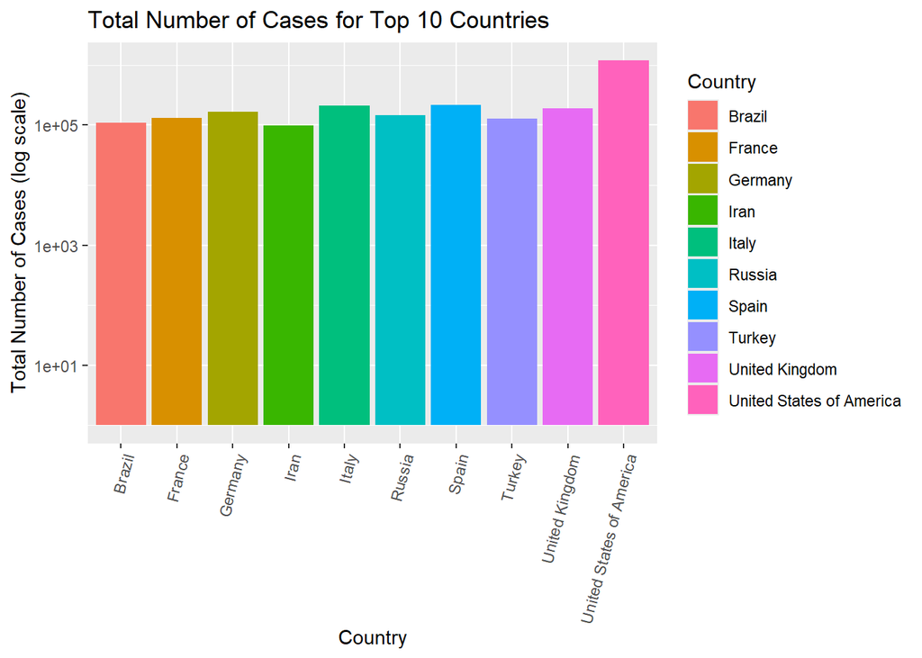

```r
# Select top 10 countries based on total confirmed cases
top10_countries_data <- head(arrange(lastDay_data, desc(CumCases)), n = 10)$Country

# Filter lastDay_data for the top 10 countries
top10_data_df <- filter(lastDay_data, Country %in% top10_countries_data)

# Create a bar plot of total cases for the top 10 countries
ggplot(top10_data_df, aes(x = Country, y = CumCases, fill = Country)) +
  geom_col() +  # Create a bar plot
  scale_y_log10() +  # Use a logarithmic scale for the y-axis
  labs(
    title = "Total Number of Cases for Top 10 Countries",  # Title of the plot
    x = "Country",  # x-axis label
    y = "Total Number of Cases (log scale)",  # y-axis label
    fill = "Country"  # Legend title
  ) +
  theme(axis.text.x = element_text(angle = 75, vjust = 1, hjust = 1))  # Adjust x-axis text for better readability
```

7. Build a graph for the top 10 countries with current highest active cases which was obtained previously in question 4. The graph should have one sub-graph (*i.e.*, using facet function) for each of these countries, every sub-graph should show how the new cases, new deaths, and new recovered cases were changing over the time (Use log for Y axis for better presentation, Use different colour to distinguish between new cases, deaths, and recovered).

   [hint: geom_line function with date on x_axis and each of the values of the variables in y_axis]

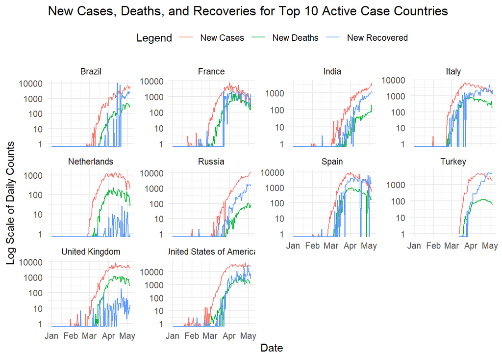

```r
# Filter data for the top 10 countries with the highest active cases (from question 4)
top10_active_countries <- top10activeW$Country  # List of countries
top10_active_data <- filter(covid19_data, Country %in% top10_active_countries)  # Filter main data

# Create faceted line plot for each country, showing trends in new cases, deaths, and recoveries
ggplot(top10_active_data, aes(x = Date)) +
  geom_line(aes(y = NewCases, color = "New Cases")) +        # Line for new cases
  geom_line(aes(y = NewDeaths, color = "New Deaths")) +      # Line for new deaths
  geom_line(aes(y = Recovered, color = "New Recovered")) + # Line for new recoveries
  scale_y_log10() +  # Use logarithmic scale for y-axis for better presentation
  labs(
    title = "New Cases, Deaths, and Recoveries for Top 10 Active Case Countries",
    x = "Date",
    y = "Log Scale of Daily Counts",
    color = "Legend"
  ) +
  facet_wrap(~Country, scales = "free_y") +  # Create a separate sub-graph for each country
  theme_minimal() +
  theme(legend.position = "top")  # Position the legend at the top for easier readability
```

8. Build a graph for the top 10 countries with current highest total tests per one million of the population which was obtained previously in question 4. This graph should present total number of infected cases, total tests so far, and the total tests per million of the population for each country.

   [hint: you can use bar chart to achieve this task]

[figure not shown]

[output not shown]

[figure not shown]

```r
# Extract COVID-19 data for the top 10 countries with the highest total tests per million population
top_tests_data <- covid19_data %>%
  # Filter the dataset to include only the countries in the top 10 for tests per million
  filter(Country %in% top10testsMW$Country) %>%
  # Group the data by country for aggregation
  group_by(Country) %>%
  # Summarize the total cases, tests, and tests per million for each country
  summarise(
    TotalCases = sum(NewCases),          # Calculate the total number of new cases
    TotalTests = sum(NewTests),          # Calculate the total number of new tests conducted
    TestsPerMillion = sum(Tests_1M_Pop)  # Calculate total tests per million population
  )

# Reshape the data to a long format using pivot_longer
long_data <- top_tests_data %>%
  # Transform the data so that metrics are in a single column, making it easier to plot
  pivot_longer(cols = c(TotalCases, TotalTests, TestsPerMillion),  # Specify the columns to pivot
               names_to = "Metric",  # Name for the new column containing the metric names
               values_to = "Count")  # Name for the new column containing the metric values

# Create a bar plot to visualize the data
ggplot(long_data, aes(x = Country, y = Count, fill = Metric)) +
  # Create a bar chart with counts side by side for each metric
  geom_bar(stat = "identity", position = "dodge") +
  # Use a logarithmic scale for the y-axis for better visibility of data distribution
  scale_y_log10(labels = scales::comma) +
  # Add labels and title to the plot
  labs(
    title = "Comparison of Total Cases, Tests, and Tests per Million in Top 10 Countries",
    x = "Country",              # Label for the x-axis
    y = "Count (Log Scale)",    # Label for the y-axis indicating the scale used
    fill = "Metric"             # Legend title for the fill colors
  ) +
  # Apply a minimal theme for a clean look
  scale_fill_manual(values = c("TotalCases" = "green",
                                "TotalTests" = "red",
                                "TestsPerMillion" = "brown")) +
  theme_minimal() +
  # Rotate x-axis text for better readability
  theme(axis.text.x = element_text(angle = 50))
```

10. Based on the data of the *“lastDay_data”* dataframe, list the top 2-countries of each continent that report the highest death toll.

```r
# Aggregate data by Continent and Country, then select countries with the highest cumulative deaths in each continent
highest_deaths_per_continent <- lastDay_data %>%

  # Group the data by continent to perform continent-specific sorting
  group_by(Continent) %>%

  # Sort each continent's data in descending order of cumulative deaths
  arrange(Continent, desc(CumDeaths)) %>%

  # Select the top 2 countries with the highest cumulative deaths in each continent
  slice_head(n = 2) %>%

  # Ungroup the data to remove the continent grouping structure
  ungroup()

# Display the resulting dataset of countries with the highest cumulative deaths per continent
highest_deaths_per_continent
```

```
## # A tibble: 12 × 23
##    Code  Country      Continent Date       NewCases NewDeaths Recovered NewTests
##    <chr> <chr>        <chr>     <date>        <int>     <int>     <int>    <int>
##  1 DZA   Algeria      Africa    2020-05-05      174         2        69        0
##  2 EGY   Egypt        Africa    2020-05-05      348         7        98        0
##  3 IRN   Iran         Asia      2020-05-05     1223        74      1096    11255
##  4 CHN   China        Asia      2020-05-05        2         0        78        0
##  5 ITA   Italy        Europe    2020-05-05     1221       195      2352    55263
##  6 GBR   United King… Europe    2020-05-05     3985       288        16    69839
##  7 USA   United Stat… North Am… 2020-05-05    22593      1252      2611        0
##  8 CAN   Canada       North Am… 2020-05-05     1298       172       976    21199
##  9 AUS   Australia    Oceania   2020-05-05       24         0        88    14542
## 10 NZL   New Zealand  Oceania   2020-05-05        2         0        14        0
## 11 BRA   Brazil       South Am… 2020-05-05     6633       296      2406        0
## 12 ECU   Ecuador      South Am… 2020-05-05     2343         5         0        0
## # ℹ 15 more variables: Population <int>, GDP <int>, GDPCapita <int>,
## #   Month <int>, Week <int>, CumCases <int>, CumDeaths <int>,
## #   CumRecovered <int>, CumTests <int>, Active <int>, FatalityRate <dbl>,
## #   Cases_1M_Pop <dbl>, Deaths_1M_Pop <dbl>, Recovered_1M_Pop <dbl>,
## #   Tests_1M_Pop <dbl>
```

11. **Summary Task 2 final Report**: This report provides an analysis of the COVID-19 pandemic, emphasizing global statistics, patterns, and major insights drawn from the data. Its aim is to offer a comprehensive overview of the pandemic’s effects across various countries and continents, underscoring essential metrics that influence public health responses.

The highest global death toll from COVID-19 was recorded on April 16, 2020, with 10,520 fatalities. Since then, cumulative global data has shown a consistent increase in the number of infections, deaths, and tests conducted. However, the number of recoveries began to rise steadily from mid-January, eventually surpassing the death rate. The attached graph visually represents the trends in global cumulative COVID-19 data.

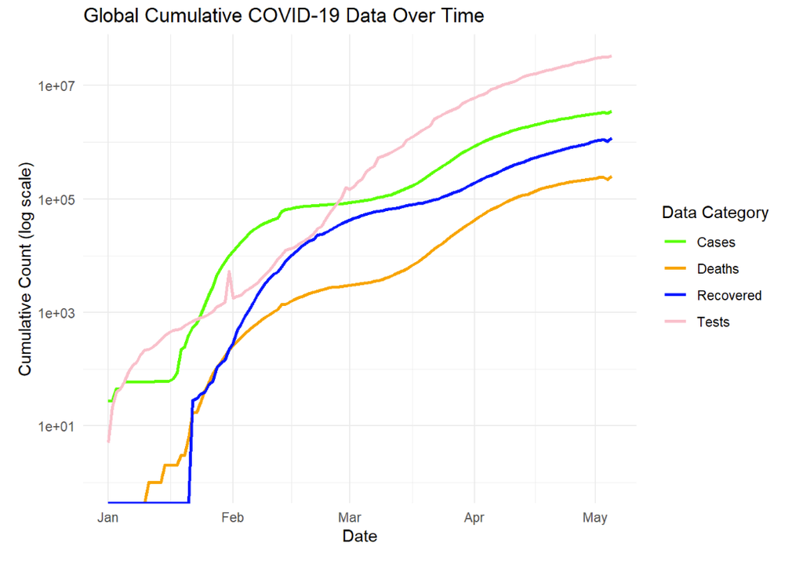

```r
knitr::include_graphics("C:/Users/NGOCNT/Pictures/Screenshots/Screenshot 2024-10-30 191255.png")
```

The dataset for May 5, 2020, includes key metrics for each country, displaying information such as country code, country name, continent, date (05/05/2020), new cases, new deaths, recovered cases, new tests, population, GDP, GDP per capita, month, week, deaths per million population, recovered cases per million population, and tests per million population. These metrics provide a snapshot of the pandemic’s status on that date, offering insights into its impact across different regions.

The top 10 countries with the highest current active COVID-19 cases are the USA, UK, Russia, Italy, Spain, France, Brazil, Turkey, Netherlands, India. The top 10 countries with the highest total confirmed COVID-19 cases are the USA, Spain, Italy, UK, Germany, Russia, France, Turkey, Brazil and Iran. The top 10 countries with the highest fatality rates include Nicaragua, Comoros, France, Sint Maarten, Yemen, Belgium, the UK, British Virgin Islands, Northern Mariana Islands, and Italy. In terms of testing, the top 10 countries based on total tests conducted are the USA, Russia, Germany, Italy, Spain, Turkey, India, the UK, Canada, and France.

The dataset includes COVID-19 statistics from six continents: Africa, Asia, Europe, North America, Oceania, and South America. Oceania has the lowest total confirmed cases, with 8,579, while Europe has the highest at 1,406,374. In terms of total deaths, Oceania also reports the fewest, with 122 fatalities, compared to Europe’s 141,780. Oceania has the lowest number of recoveries at 7,313, whereas Europe leads with 537,696 recoveries, which is expected given the disparity in confirmed cases between the two regions. Testing efforts differ significantly, with Europe conducting the most tests at 17,013,488 and Africa the least at 618,154.

Among the countries with the highest death tolls in each continent, the leading two in Africa are Algeria and Egypt; in Asia, they are Iran and China; in Europe, Italy and the United Kingdom; in North America, the USA and Canada; in Oceania, Australia and New Zealand; and in South America, Brazil and Ecuador. This data provides a comparative perspective on the pandemic’s impact across continents and highlights key countries facing significant challenges in each region.

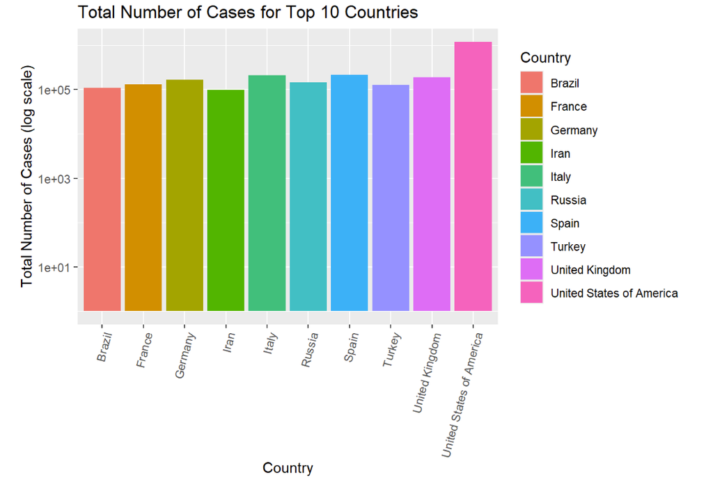

```r
knitr::include_graphics("C:/Users/NGOCNT/Pictures/Screenshots/Screenshot 2024-10-30 191312.png")
```

Another graph displays the total number of infected cases, total tests conducted so far, and tests per million of the population for each country, created by this code.

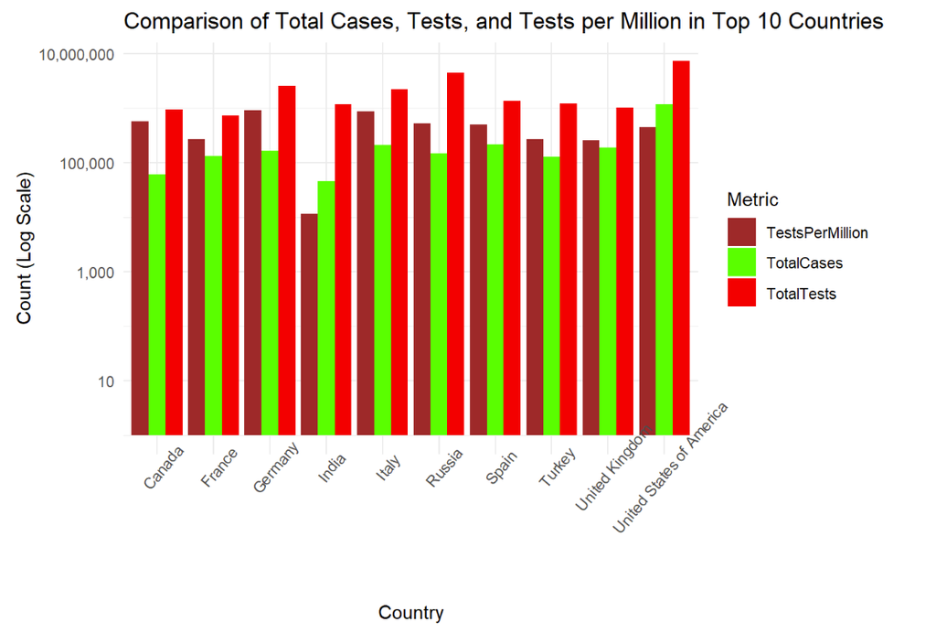

```r
knitr::include_graphics("C:/Users/NGOCNT/Pictures/Screenshots/Screenshot 2024-10-30 191320.png")
```

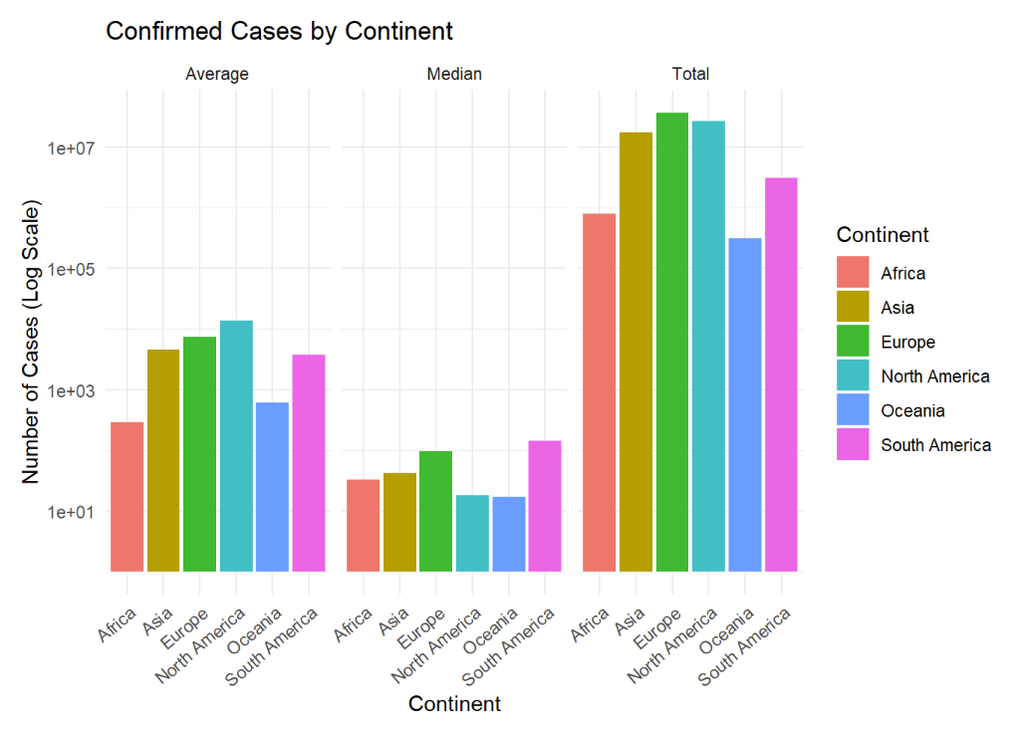

```r
knitr::include_graphics("C:/Users/NGOCNT/Pictures/Screenshots/Screenshot 2024-10-30 191332.png")
```

…